# Introduction to R

visualising RNA-seq data with the tidyverse (volcano plot)

Maria Doyle and Liz Christie

10 May 2019

#### Acknowledgements

Material created by Peter Mac Data Science.

## Objectives

- Demonstrate how R can be used to visualise RNA-Seq data with volcano plots
- Demonstrate basic R syntax (`ifelse()`, `c()`, `%in%`, `$`)
- Utilize dplyr’s `mutate` to add columns to tables.
- Utilize ggplot2’s `geom_point()`
- Utilize ggrepel’s `ggplot_text_repel`()

## Introduction

In this tutorial, we will learn some R through creating volcano plots from an RNA-seq experiment.

### RNA-seq dataset

We will again use the published RNA-seq data from the Nature Cell Biology paper by [Fu et al. 2015](https://www.ncbi.nlm.nih.gov/pubmed/25730472). This study examined expression in basal and luminal cells from mice at different stages (virgin, pregnant and lactating).

In the previous tutorial we explored the counts for each sample. Today we will work with the differential expression results. We will use the results from comparing the luminal cells from the mammary gland of the pregnant and lactating mice.This is a file that contains the log fold changes and P values for the genes.

### Packages

We have already seen some **tidyverse** packages: **readr** for reading in files, **ggplot2** for plotting. Today we will use those packages again aswell as another really useful tidyverse package called **dplyr** that can be used to manipulate tables. We will also use a non-tidyverse R package called [ggrepel](https://cran.r-project.org/web/packages/ggrepel/vignettes/ggrepel.html).

## Loading the data

First let’s open a new R script. From the top menu in RStudio: `File > New File > R Script`. Let’s save it as `volcano_plots.R`.

We will begin by loading in the packages that we need. These are already installed for you but if you need to install them on your own computer you can use `install.packages()`.

```r
library(tidyverse)
library(ggrepel)
```

Next we load in our RNA-seq data. The file we will use is tab-separated, so we will use the `read_tsv()` function from the tidyverse readr package to read it in. We will store the contents of our file in an object called `de_results`.

```r
de_results <- read_tsv("data/limma-voom_luminalpregnant-luminallactate.tsv.gz")
```

We can type `de_results` to have a look at the data.

```r
de_results
```

| ENTREZID | SYMBOL | GENENAME | logFC | AveExpr | t | P.Value | adj.P.Val | B |
| --- | --- | --- | --- | --- | --- | --- | --- | --- |
| 12992 | Csn1s2b | casein alpha s2-like B | -8.6036111 | 3.56295004 | -46.962400 | 2.732470e-15 | 4.318396e-11 | 24.275762 |
| 13358 | Slc25a1 | solute carrier family 25 (mitochondrial carrier, citrate transporter), member 1 | -4.1241753 | 5.77969894 | -34.802233 | 5.062272e-14 | 4.000207e-10 | 22.454454 |
| 20531 | Slc34a2 | solute carrier family 34 (sodium phosphate), member 2 | -4.1778124 | 4.27862904 | -31.437092 | 1.825858e-13 | 9.618621e-10 | 21.296633 |
| 11941 | Atp2b2 | ATPase, Ca++ transporting, plasma membrane 2 | -7.3869864 | 1.28214315 | -30.189903 | 3.040048e-13 | 1.201123e-09 | 19.573001 |
| 100705 | Acacb | acetyl-Coenzyme A carboxylase beta | -4.3143199 | 4.44091371 | -29.141192 | 4.743168e-13 | 1.289680e-09 | 20.337203 |
| 230810 | Slc30a2 | solute carrier family 30 (zinc transporter), member 2 | -3.2031181 | 2.69581148 | -29.067663 | 4.896281e-13 | 1.289680e-09 | 20.286555 |
| 68801 | Elovl5 | ELOVL family member 5, elongation of long chain fatty acids (yeast) | -2.8633040 | 6.45520453 | -28.031782 | 7.725733e-13 | 1.744250e-09 | 19.945967 |
| 13645 | Egf | epidermal growth factor | -5.3626638 | 0.73590465 | -27.582493 | 9.463856e-13 | 1.869585e-09 | 18.005140 |
| 26366 | Ceacam10 | carcinoembryonic antigen-related cell adhesion molecule 10 | -3.2956212 | 1.82101424 | -25.411460 | 2.645520e-12 | 4.645533e-09 | 18.674329 |
| 68603 | Pmvk | phosphomevalonate kinase | -2.6769833 | 4.72310684 | -25.016839 | 3.218091e-12 | 5.085870e-09 | 18.520052 |

[output cut: 990 more lines]

We can’t see all the columns here but we can look at all the data with `View()` or use the R function `colnames()` if we just want to see the column names.

```r
View(de_results)
```

```r
colnames(de_results)
```

## Creating a volcano plot

To make a volcano plot we make a scatterplot using `geom_point()` and plot the log fold change (logFC) vs the negative log10 P value. Why do we use the negative log 10 P value and not just the P value? Let’s have a look at what happens if we plot the P value as is versus the logFC. We use the columns called logFC and P.Value.

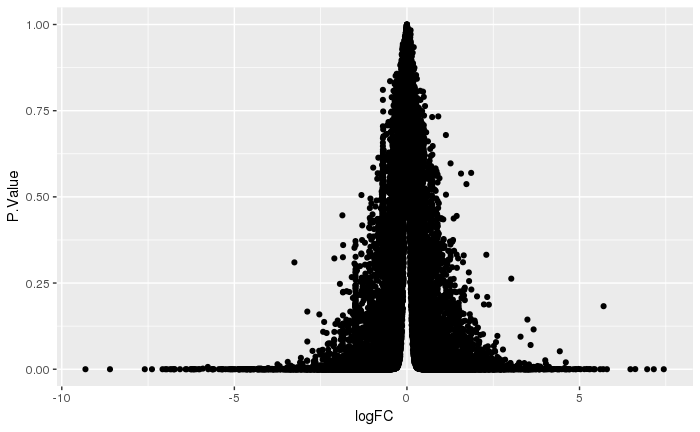

```r
ggplot(de_results, aes(logFC, P.Value)) +
    geom_point()
```

Genes with small P values are the most significant and in this plot they are all squashed at the bottom of the plot, not very easy to see. Let’s see what happens when we use log10.

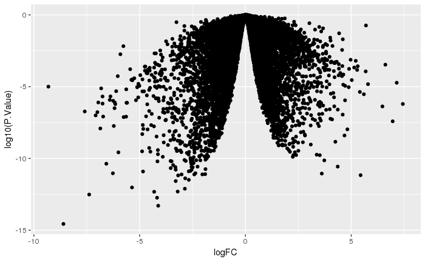

```r
ggplot(de_results, aes(logFC, log10(P.Value))) +
    geom_point()
```

Looks better but this still has the most significant genes at the bottom and the usual way is to plot the most significant at the top so we use the negative log10 (-log10). Let’s try that.

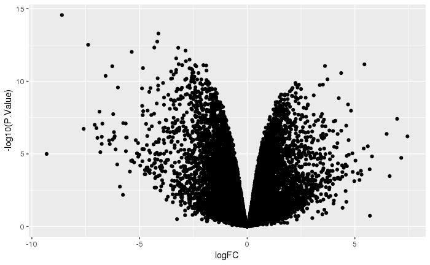

```r
ggplot(de_results, aes(logFC, -log10(P.Value))) +
    geom_point()
```

## Highlighting significant genes

### Using a P value threshold

Let’s colour genes that are significant. We will call genes significantly differentially expressed if they have an adjusted P Value below 0.05. An adjusted P value means the P value has been adjusted for multiple testing, as we are testing many thousands of genes. This is what we filter on in RNA-Seq.

Remember we saw in the previous tutorial that we can use a column to colour features of our data with `fill=` or `col=`. In this case we are colouring points so we use `col=`.

We will add a column that says whether genes are significant or not. To add columns we use dplyr’s `mutate()`.

Let’s have a look at `mutate` first to see how it works. We give mutate our data (`de_results`), then a name for the column we want to create.

Let’s make a column called signif (for significance). Then we put what we want to have in the column in brackets after the column name. For example, if we wanted to label every gene as significant we could write below. We’ll try running it and store it in an object called `testing` as we’re just seeing how it works.

```r
testing <- mutate(de_results, signif=("Signif"))
```

We can use View() to have a look at dataset. There should be a new column called signif at the end with “Signif” in every row. mutate always adds the column to the *end* of the table.

```r
View(testing)
```

#### Exercise

Add another column called labels to the `testing` object that contains the value “Labels” in every row.